# Methods for Handling Multiple Outcomes in Health Data

SECOMBIT Study

#libraries

```r
library(dplyr)
library(ggplot2)
library(readxl)
library(survival)
library(survminer)
library(tableone)
library(mice)
library(plotly)
library(table1)
library(tidyr)
library(readr)
library(readxl)
library(dplyr)
library(table1)
library(survival)
library(survminer)
library(WinRatio)
library(BuyseTest)
library(msm)
```

```r
SECOMBIT <- read.csv("Secombit data.csv", check.names = FALSE)

# Clean the data to improve readability
clean_df <- SECOMBIT %>%
  mutate(

    # ID
    id = ordine,

    # Overall Survival
    os_time   = OS,
    os_status = status,

    # Progression-Free Survival
    pfs_time   = `PFS TOTAL`,
    pfs_status = `Progr total`,

    # Treatment arm (A as baseline)
    Arm = factor(ARM, levels = c("A", "B", "C")),

    # Number of sites (1–2 as baseline)
    Sites = factor(sites, levels = c("1-2", ">=3"),
                   labels = c("1 - 2", ">= 3")),

    # LDH (Normal as baseline)
    LDH = factor(ULN_LDH, levels = c("normal", "elevated"),
                 labels = c("Normal", "Elevated")),

    # TMB (<10 as baseline)
    TMB = factor(TMB, levels = c("<10", ">=10"),
                 labels = c("< 10", ">= 10")),

    # JAK (Wild Type as baseline)
    JAK = factor(JAK, levels = c("wt", "mut"),
                 labels = c("Wild Type (Normal)", "Mutated")),

  ) %>%
  select(id, Arm, Sites, LDH, TMB, JAK, pfs_time, pfs_status, os_time, os_status)
```

```r
names(clean_df)
```

```
##  [1] "id"         "Arm"        "Sites"      "LDH"        "TMB"
##  [6] "JAK"        "pfs_time"   "pfs_status" "os_time"    "os_status"
```

## Numeric summary

```r
numeric_summary <- SECOMBIT %>%
summarise(
mean_OS    = mean(OS, na.rm = TRUE),
sd_OS      = sd(OS, na.rm = TRUE),
median_OS  = median(OS, na.rm = TRUE),
min_OS     = min(OS, na.rm = TRUE),
max_OS     = max(OS, na.rm = TRUE),
mean_PFS   = mean(`PFS TOTAL`, na.rm = TRUE),
sd_PFS     = sd(`PFS TOTAL`, na.rm = TRUE),
median_PFS = median(`PFS TOTAL`, na.rm = TRUE),
min_PFS    = min(`PFS TOTAL`, na.rm = TRUE),
max_PFS    = max(`PFS TOTAL`, na.rm =TRUE)
)

numeric_summary
```

```
##    mean_OS    sd_OS median_OS min_OS max_OS mean_PFS   sd_PFS median_PFS
## 1 32.39015 17.19042      35.9   1.13   65.5 28.80602 18.06442       29.8
##   min_PFS max_PFS
## 1     1.1    65.5
```

## Summary statistics for categorical variables

```r
label(clean_df$Sites) <- "Sites"
label(clean_df$LDH)   <- "LDH"
label(clean_df$TMB)   <- "TMB"
label(clean_df$JAK)   <- "JAK"

table1(~ Sites + LDH + TMB + JAK | Arm,
       data = clean_df,
       overall = FALSE)
```

|  | A (N=69) | B (N=71) | C (N=69) |
| --- | --- | --- | --- |
| Sites |  |  |  |
| 1 - 2 | 43 (62.3%) | 41 (57.7%) | 42 (60.9%) |
| >= 3 | 26 (37.7%) | 29 (40.8%) | 26 (37.7%) |
| Missing | 0 (0%) | 1 (1.4%) | 1 (1.4%) |
| LDH |  |  |  |
| Normal | 41 (59.4%) | 41 (57.7%) | 48 (69.6%) |
| Elevated | 26 (37.7%) | 28 (39.4%) | 20 (29.0%) |
| Missing | 2 (2.9%) | 2 (2.8%) | 1 (1.4%) |
| TMB |  |  |  |
| < 10 | 20 (29.0%) | 17 (23.9%) | 18 (26.1%) |
| >= 10 | 8 (11.6%) | 8 (11.3%) | 12 (17.4%) |
| Missing | 41 (59.4%) | 46 (64.8%) | 39 (56.5%) |
| JAK |  |  |  |
| Wild Type (Normal) | 24 (34.8%) | 17 (23.9%) | 16 (23.2%) |
| Mutated | 5 (7.2%) | 7 (9.9%) | 14 (20.3%) |
| Missing | 40 (58.0%) | 47 (66.2%) | 39 (56.5%) |

```r
table_cat <- table1(~ LDH | Arm, data = clean_df)
table_cat
```

|  | A (N=69) | B (N=71) | C (N=69) | Overall (N=209) |
| --- | --- | --- | --- | --- |
| LDH |  |  |  |  |
| Normal | 41 (59.4%) | 41 (57.7%) | 48 (69.6%) | 130 (62.2%) |
| Elevated | 26 (37.7%) | 28 (39.4%) | 20 (29.0%) | 74 (35.4%) |
| Missing | 2 (2.9%) | 2 (2.8%) | 1 (1.4%) | 5 (2.4%) |

```r
mortality_plot <- ggplot(clean_df, aes(x = Arm, fill = as.factor(LDH)))+
geom_bar(position = "dodge")+
labs(
title = "LDH levels by ARM",
x = "ARM",
y = "Levels",
fill = "LDH"
) +
scale_fill_manual(values = c("pink", "black", "yellow"),
labels = c("Missing","Normal", "Elevated")) +
theme_minimal()

ggplotly(mortality_plot)
```

[interactive chart not shown]

## ARM-wise summary

```r
arm_summary <- clean_df %>%
group_by(Arm) %>%
summarise(
n = n(),
mean_OS = mean(os_status, na.rm = TRUE),
sd_OS = sd(os_status, na.rm = TRUE),
mean_PFS = mean(pfs_status, na.rm = TRUE),
sd_PFS = sd(pfs_status, na.rm = TRUE),
.groups = "drop"
)

arm_summary
```

```
## # A tibble: 3 × 6
##   Arm       n mean_OS sd_OS mean_PFS sd_PFS
##   <fct> <int>   <dbl> <dbl>    <dbl>  <dbl>
## 1 A        69   0.507 0.504    0.710  0.457
## 2 B        71   0.333 0.475    0.435  0.499
## 3 C        69   0.397 0.493    0.471  0.503
```

```r
event_count <- clean_df %>%
  group_by(Arm)  %>%
  summarise(
    OS_Events = sum(os_status == 1, na.rm = TRUE),
    PFS_Events = sum(pfs_status == 1, na.rm = TRUE),
    .groups = "drop"
  )
event_count
```

```
## # A tibble: 3 × 3
##   Arm   OS_Events PFS_Events
##   <fct>     <int>      <int>
## 1 A            35         49
## 2 B            23         30
## 3 C            27         32
```

```r
event_long <- event_count %>%
  pivot_longer(
    cols = c(OS_Events, PFS_Events),
    names_to = "Endpoint",
    values_to = "Events"
  )

plot_events <- ggplot(event_long, aes(x = Arm, y = Events, fill = Endpoint)) +
  geom_col (position = position_dodge(width = 0.7))+
  labs(
    title = "OS and PFS : Event Vs Arms",
    x = "ARM",
    y = "No. of events",
    fill = "Endpoint",
  ) +
scale_fill_manual(values = c("OS_Events"  = "red",
                             "PFS_Events" = "blue"))+
theme_minimal()

ggplotly(plot_events)
```

[interactive chart not shown]

## Baseline variables

```r
vars <- c("Sites", "LDH", "TMB", "JAK", "os_status", "pfs_status")
factorVars <- c("Sites", "LDH", "TMB", "JAK")

tab1 <- CreateTableOne(
vars = vars,
strata = "Arm",
data = clean_df,
factorVars = factorVars
)

print(tab1, showAllLevels = TRUE, quote = FALSE, noSpaces = TRUE)
```

```
##                         Stratified by Arm
##                          level              A           B           C
##   n                                         69          71          69
##   Sites (%)              1 - 2              43 (62.3)   41 (58.6)   42 (61.8)
##                          >= 3               26 (37.7)   29 (41.4)   26 (38.2)
##   LDH (%)                Normal             41 (61.2)   41 (59.4)   48 (70.6)
##                          Elevated           26 (38.8)   28 (40.6)   20 (29.4)
##   TMB (%)                < 10               20 (71.4)   17 (68.0)   18 (60.0)
##                          >= 10              8 (28.6)    8 (32.0)    12 (40.0)
##   JAK (%)                Wild Type (Normal) 24 (82.8)   17 (70.8)   16 (53.3)
##                          Mutated            5 (17.2)    7 (29.2)    14 (46.7)
##   os_status (mean (SD))                     0.51 (0.50) 0.33 (0.47) 0.40 (0.49)
##   pfs_status (mean (SD))                    0.71 (0.46) 0.43 (0.50) 0.47 (0.50)
##                         Stratified by Arm
##                          p     test
##   n
##   Sites (%)              0.887
##
##   LDH (%)                0.346
##
##   TMB (%)                0.639
##
##   JAK (%)                0.050
##
##   os_status (mean (SD))  0.111
##   pfs_status (mean (SD)) 0.002
```

## **Composite Outcomes**

```r
clean_df$comp_status = ifelse(clean_df$os_status == 1 | clean_df$pfs_status == 1, 1, 0)
clean_df$comp_time = pmin(clean_df$os_time, clean_df$pfs_time, na.rm = TRUE)

table1(~comp_status + comp_time | Arm, data = clean_df)
```

|  | A (N=69) | B (N=71) | C (N=69) | Overall (N=209) |
| --- | --- | --- | --- | --- |
| comp_status |  |  |  |  |
| Mean (SD) | 0.710 (0.457) | 0.435 (0.499) | 0.471 (0.503) | 0.539 (0.500) |
| Median [Min, Max] | 1.00 [0, 1.00] | 0 [0, 1.00] | 0 [0, 1.00] | 1.00 [0, 1.00] |
| Missing | 0 (0%) | 2 (2.8%) | 1 (1.4%) | 3 (1.4%) |
| comp_time |  |  |  |  |
| Mean (SD) | 26.8 (17.6) | 29.3 (18.8) | 30.3 (17.8) | 28.8 (18.1) |
| Median [Min, Max] | 23.0 [1.10, 65.5] | 32.7 [1.30, 65.5] | 31.6 [1.90, 63.7] | 29.8 [1.10, 65.5] |
| Missing | 0 (0%) | 2 (2.8%) | 1 (1.4%) | 3 (1.4%) |

## Binary outcome

```r
clean_df <- clean_df %>%
  mutate(
    binary_os = os_status,
    binary_pfs = pfs_status,
    binary_comp = comp_status
  ) %>%
  mutate(across(c(binary_os, binary_pfs, binary_comp), ~factor (.x, labels = c("No Event", "Event"))))


table(clean_df$binary_os, clean_df$Arm)
```

```
##
##             A  B  C
##   No Event 34 46 41
##   Event    35 23 27
```

```r
table(clean_df$binary_pfs, clean_df$Arm)
```

```
##
##             A  B  C
##   No Event 20 39 36
##   Event    49 30 32
```

```r
table(clean_df$binary_comp, clean_df$Arm)
```

```
##
##             A  B  C
##   No Event 20 39 36
##   Event    49 30 32
```

## Logistic Regression

```r
log_os <- glm(binary_os ~ Arm + Sites + LDH + TMB + JAK, family = binomial, data = clean_df)

log_pfs <- glm(binary_pfs ~ Arm + Sites + LDH + TMB + JAK, family = binomial, data = clean_df)

log_comp <- glm(binary_comp ~ Arm + Sites + LDH + TMB + JAK, family = binomial, data = clean_df)

tidy_logistic <- function(fit, title){
  broom::tidy(fit, exponentiate = TRUE, conf.int = TRUE) |>
    mutate(
      OR_CI = sprintf("%.2f (%.2f–%.2f)", estimate, conf.low, conf.high),
      p = signif(p.value, 3)
    ) |>
    select(term, OR_CI, p) |>
    rename(Variable = term, `OR (95% CI)` = OR_CI, `p-value` = p) |>
    (function(df){
      cat(paste0("<b>", title, "</b>"))
      knitr::kable(df, format = "html", escape = FALSE) |>
        kableExtra::kable_styling(full_width = TRUE, font_size = 18)
    })()
}

tidy_logistic(log_os, "Logistic — OS Event")
```

```
## <b>Logistic — OS Event</b>
```

| Variable | OR (95% CI) | p-value |
| --- | --- | --- |
| (Intercept) | 0.64 (0.25–1.61) | 0.3490 |
| ArmB | 0.70 (0.20–2.34) | 0.5700 |
| ArmC | 0.83 (0.25–2.70) | 0.7500 |
| Sites>= 3 | 2.45 (0.88–7.13) | 0.0908 |
| LDHElevated | 0.79 (0.26–2.27) | 0.6650 |
| TMB>= 10 | 0.71 (0.23–2.03) | 0.5230 |
| JAKMutated | 0.52 (0.15–1.64) | 0.2730 |

```r
cat("<br>")
```

```
## <br>
```

```r
tidy_logistic(log_pfs, "Logistic — PFS Event")
```

```
## <b>Logistic — PFS Event</b>
```

| Variable | OR (95% CI) | p-value |
| --- | --- | --- |
| (Intercept) | 1.33 (0.53–3.42) | 0.5450 |
| ArmB | 0.43 (0.12–1.44) | 0.1800 |
| ArmC | 1.08 (0.34–3.59) | 0.8940 |
| Sites>= 3 | 1.83 (0.65–5.37) | 0.2590 |
| LDHElevated | 0.90 (0.30–2.62) | 0.8410 |
| TMB>= 10 | 0.72 (0.25–2.07) | 0.5460 |
| JAKMutated | 0.26 (0.07–0.80) | 0.0247 |

```r
cat("<br>")
```

```
## <br>
```

```r
tidy_logistic(log_comp, "Logistic — Composite Event")
```

```
## <b>Logistic — Composite Event</b>
```

| Variable | OR (95% CI) | p-value |
| --- | --- | --- |
| (Intercept) | 1.33 (0.53–3.42) | 0.5450 |
| ArmB | 0.43 (0.12–1.44) | 0.1800 |
| ArmC | 1.08 (0.34–3.59) | 0.8940 |
| Sites>= 3 | 1.83 (0.65–5.37) | 0.2590 |
| LDHElevated | 0.90 (0.30–2.62) | 0.8410 |
| TMB>= 10 | 0.72 (0.25–2.07) | 0.5460 |
| JAKMutated | 0.26 (0.07–0.80) | 0.0247 |

## Logistic Regression and COX for ARM

```r
log_os_arm <- glm(binary_os ~ Arm, family = binomial, data = clean_df)

log_pfs_arm <- glm(binary_pfs ~ Arm, family = binomial, data = clean_df)

log_comp_arm <- glm(binary_comp ~ Arm, family = binomial, data = clean_df)

tidy_logistic <- function(fit, title){
  broom::tidy(fit, exponentiate = TRUE, conf.int = TRUE) |>
    mutate(
      OR_CI = sprintf("%.2f (%.2f–%.2f)", estimate, conf.low, conf.high),
      p = signif(p.value, 3)
    ) |>
    select(term, OR_CI, p) |>
    rename(Variable = term, `OR (95% CI)` = OR_CI, `p-value` = p) |>
    (function(df){
      cat(paste0("<b>", title, "</b>"))
      knitr::kable(df, format = "html", escape = FALSE) |>
        kableExtra::kable_styling(full_width = TRUE, font_size = 18)
    })()
}

tidy_logistic(log_os_arm, "Logistic — OS Event by ARM")
```

```
## <b>Logistic — OS Event by ARM</b>
```

| Variable | OR (95% CI) | p-value |
| --- | --- | --- |
| (Intercept) | 1.03 (0.64–1.65) | 0.9040 |
| ArmB | 0.49 (0.24–0.96) | 0.0397 |
| ArmC | 0.64 (0.32–1.26) | 0.1960 |

```r
cat("<br>")
```

```
## <br>
```

```r
tidy_logistic(log_pfs_arm, "Logistic — PFS Event by ARM")
```

```
## <b>Logistic — PFS Event by ARM</b>
```

| Variable | OR (95% CI) | p-value |
| --- | --- | --- |
| (Intercept) | 2.45 (1.48–4.21) | 0.000733 |
| ArmB | 0.31 (0.15–0.63) | 0.001280 |
| ArmC | 0.36 (0.18–0.73) | 0.004830 |

```r
cat("<br>")
```

```
## <br>
```

```r
tidy_logistic(log_comp_arm, "Logistic — Composite Event by ARM")
```

```
## <b>Logistic — Composite Event by ARM</b>
```

| Variable | OR (95% CI) | p-value |
| --- | --- | --- |
| (Intercept) | 2.45 (1.48–4.21) | 0.000733 |
| ArmB | 0.31 (0.15–0.63) | 0.001280 |
| ArmC | 0.36 (0.18–0.73) | 0.004830 |

```r
cox_os_arm  <- coxph(Surv(os_time, os_status) ~ Arm,
                 data = clean_df, ties = "efron")
cox_pfs_arm <- coxph(Surv(pfs_time, pfs_status) ~ Arm,
                 data = clean_df, ties = "efron")

cox_comp_arm <- coxph(Surv(comp_time, comp_status) ~ Arm,
                  data = clean_df, ties = "efron")

tidy_cox <- function(fit, title){
  broom::tidy(fit, exponentiate = TRUE, conf.int = TRUE) |>
    mutate(
      HR_CI = sprintf("%.2f (%.2f–%.2f)", estimate, conf.low, conf.high),
      p = signif(p.value, 3)
    ) |>
    select(term, HR_CI, p) |>
    rename(Variable = term, `HR (95% CI)` = HR_CI, `p-value` = p) |>
    (\(df){
      cat(paste0("<b>", title, "</b>"))
      knitr::kable(df, format="html", escape=TRUE) |>
        kableExtra::kable_styling(full_width=TRUE, font_size=18)
    })()
}

tidy_cox(cox_os_arm,  "Cox model — Overall Survival (OS) by ARM")
```

```
## <b>Cox model — Overall Survival (OS) by ARM</b>
```

| Variable | HR (95% CI) | p-value |
| --- | --- | --- |
| ArmB | 0.66 (0.39–1.12) | 0.125 |
| ArmC | 0.73 (0.44–1.21) | 0.221 |

```r
cat("<br>")
```

```
## <br>
```

```r
tidy_cox(cox_pfs_arm, "Cox model — Progression-Free Survival (PFS) by ARM")
```

```
## <b>Cox model — Progression-Free Survival (PFS) by ARM</b>
```

| Variable | HR (95% CI) | p-value |
| --- | --- | --- |
| ArmB | 0.58 (0.37–0.91) | 0.0187 |
| ArmC | 0.60 (0.39–0.94) | 0.0260 |

```r
cat("<br>")
```

```
## <br>
```

```r
tidy_cox(cox_comp_arm, "Cox model — Composite Outcome by ARM")
```

```
## <b>Cox model — Composite Outcome by ARM</b>
```

| Variable | HR (95% CI) | p-value |
| --- | --- | --- |
| ArmB | 0.58 (0.37–0.91) | 0.0187 |
| ArmC | 0.60 (0.39–0.94) | 0.0260 |

## Univariate Analysis

## KM Plot - OS and PFS

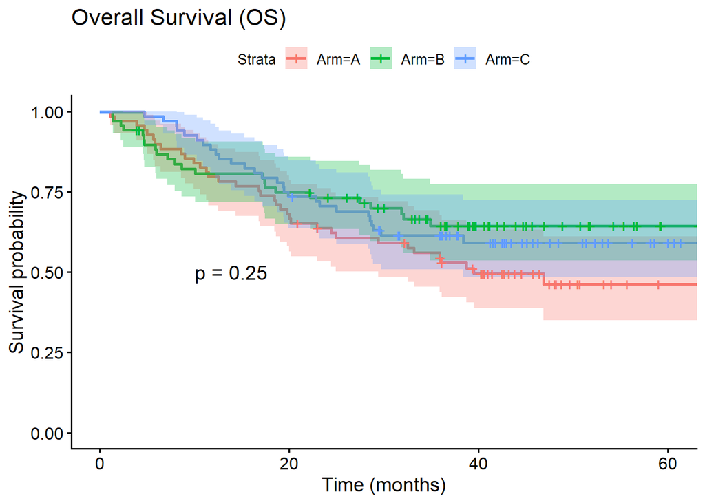

```r
par(mar = c(3, 3, 1.1, 1))
fit_os <- survfit(Surv(os_time, os_status) ~ Arm, data = clean_df)

os_km <- ggsurvplot(
  fit_os, data = clean_df,
  xlab = "Time (months)", ylab = "Survival probability",
  title = "Overall Survival (OS)",
  risk.table = FALSE, pval = TRUE, conf.int = TRUE, pval.coord = c(10,0.5),
)
#os_km$plot <- os_km$plot + geom_vline(xintercept = 2, linetype = "dashed") +
  #annotate("text", x = 2, y = 0.2, label = "2 months", angle = 90, vjust = -1)

os_km
```

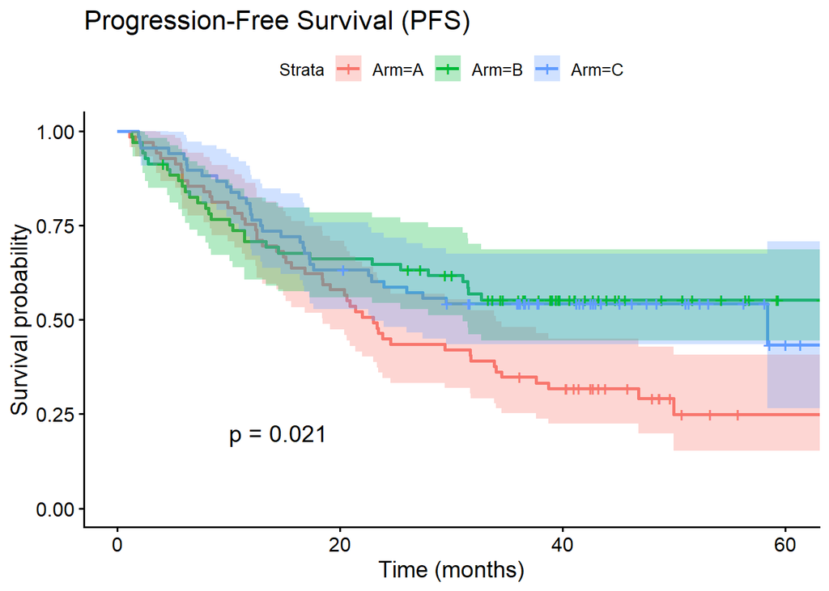

```r
par(mar = c(3, 3, 1.1, 1))
fit_pfs <- survfit(Surv(pfs_time, pfs_status) ~ Arm, data = clean_df)

pfs_km <- ggsurvplot(
  fit_pfs, data = clean_df,
  xlab = "Time (months)", ylab = "Survival probability",
  title = "Progression-Free Survival (PFS)",
 risk.table = FALSE, pval = TRUE, conf.int = TRUE, pval.coord = c(10,0.2)
)

#pfs_km$plot <- pfs_km$plot + geom_vline(xintercept = 2, linetype = "dashed")+
  #annotate("text", x = 2, y = 0.2, label = "2 months", angle = 90, vjust = -1)

pfs_km
```

## KM plot for composite outcome

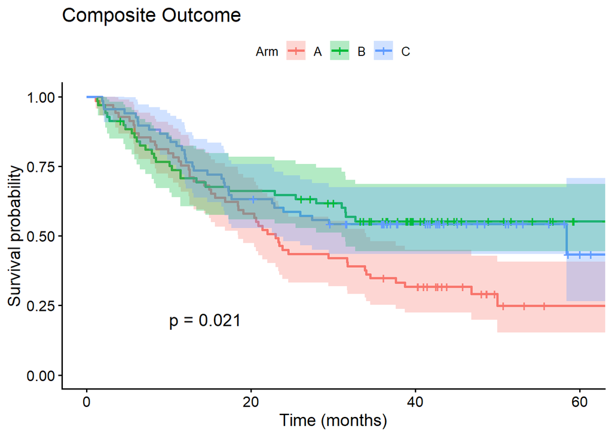

```r
par(mar = c(3, 3, 1.1, 1))
fit_comp <- survfit(Surv(comp_time, comp_status) ~ Arm, data = clean_df)

comp_km <- ggsurvplot(
  fit_comp, data = clean_df,
  xlab = "Time (months)", ylab = "Survival probability",
  title = "Composite Outcome",
  risk.table = FALSE, pval = TRUE, conf.int = TRUE,
  legend.title = "Arm", legend.labs = levels(clean_df$Arm),pval.coord = c(10,0.2)
)
#comp_km$plot <- comp_km$plot + geom_vline(xintercept = 2, linetype = "dashed")+
  #annotate("text", x = 2, y = 0.2, label = "2 months", angle = 90, vjust = -1)

comp_km
```

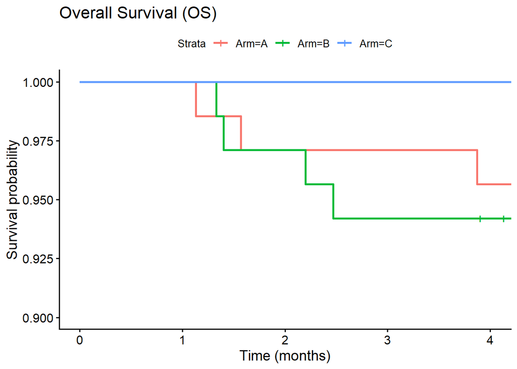

```r
os_km_2 <- ggsurvplot(
  fit_os, data = clean_df,
  xlab = "Time (months)", ylab = "Survival probability",
  title = "Overall Survival (OS)",
  risk.table = FALSE, pval = TRUE, pval.coord = c(10,0.5), xlim = c(0,4), ylim = c(0.9,1.0),break.time.by = 1
)

os_km_2
```

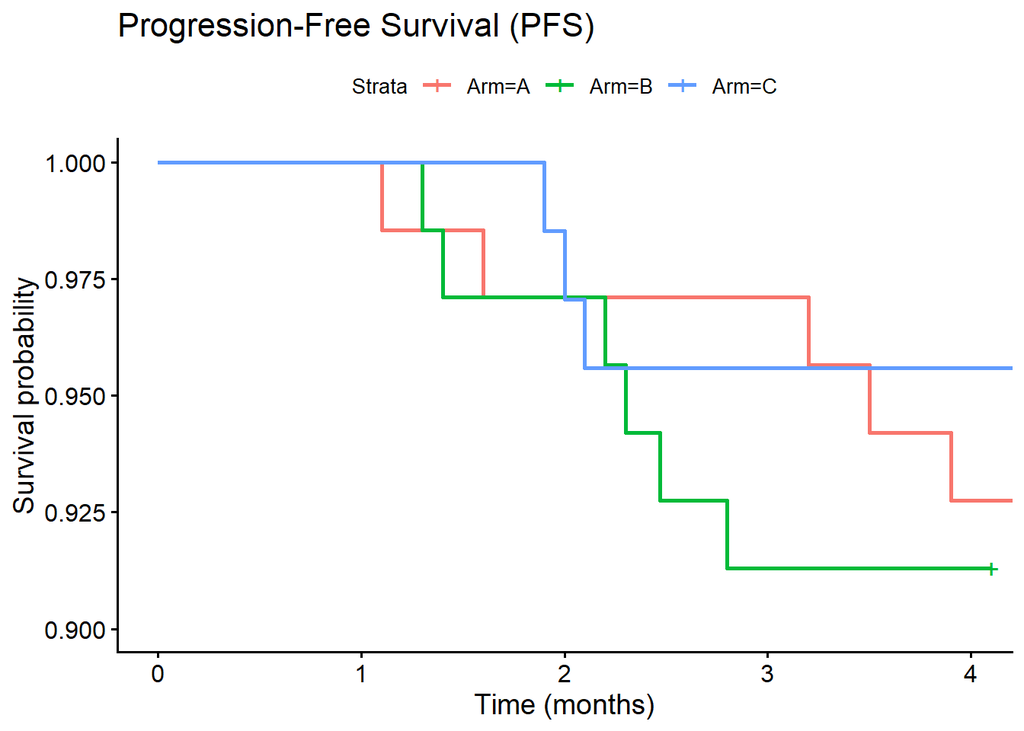

```r
pfs_km_2 <- ggsurvplot(
  fit_pfs, data = clean_df,
  xlab = "Time (months)", ylab = "Survival probability",
  title = "Progression-Free Survival (PFS)",
 risk.table = FALSE, pval = TRUE, pval.coord = c(10,0.2), xlim = c(0,4), ylim = c(0.9,1.0), break.time.by = 1
)

pfs_km_2
```

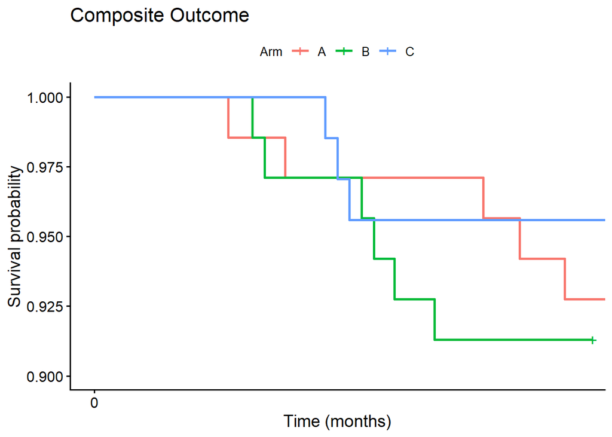

```r
comp_km_2 <- ggsurvplot(
  fit_comp, data = clean_df,
  xlab = "Time (months)", ylab = "Survival probability",
  title = "Composite Outcome",
  risk.table = FALSE, pval = TRUE,
  legend.title = "Arm", legend.labs = levels(clean_df$Arm),pval.coord = c(10,0.2), xlim = c(0,4), ylim = c(0.9,1.0), break.by.time = 1
)

comp_km_2
```

## LogRank test - OS and PFS

```r
logrank_os  <- survdiff(Surv(os_time, os_status) ~ Arm, data = clean_df)
logrank_pfs <- survdiff(Surv(pfs_time, pfs_status) ~ Arm, data = clean_df)


p_os  <- 1 - pchisq(logrank_os$chisq,  df = length(logrank_os$n)  - 1)
p_pfs <- 1 - pchisq(logrank_pfs$chisq, df = length(logrank_pfs$n) - 1)

logrank_tab <- data.frame(
  Endpoint = c("OS", "PFS"),
  `Chi-square` = round(c(logrank_os$chisq, logrank_pfs$chisq), 2),
  df = c(length(logrank_os$n)-1, length(logrank_pfs$n)-1),
  `p-value` = signif(c(p_os, p_pfs), 3)
)

knitr::kable(logrank_tab, format = "html", align = "lccc") |>
  kableExtra::kable_styling(full_width = TRUE, font_size = 16)
```

| Endpoint | Chi.square | df | p.value |
| --- | --- | --- | --- |
| OS | 2.80 | 2 | 0.2460 |
| PFS | 7.74 | 2 | 0.0208 |

**Inference - Survival curves and Cox Log-Rank tests**

Survival curves and log‑rank tests The Kaplan–Meier curves for OS appear relatively close, and the log‑rank test p‑value around 0.25 suggests no statistically significant difference in overall survival across arms at this stage.

The PFS curves separate more clearly, with a log‑rank p‑value near 0.02, indicating evidence that at least one arm differs in progression‑free survival, consistent with SECOMBIT reports that sequencing can affect progression endpoints.

# LogRank test - Composite Outcome

```r
logrank_comp  <- survdiff(Surv(comp_time, comp_status) ~ Arm, data = clean_df)

p_comp  <- 1 - pchisq(logrank_comp$chisq,  df = length(logrank_comp$n)  - 1)


logrank_tab <- data.frame(
  Endpoint = "Composite Outcome",
  `Chi-square` = round((logrank_comp$chisq), 2),
  df = length(logrank_comp$n)-1,
  `p-value` = signif(p_comp, 3)
)

knitr::kable(logrank_tab, format = "html", align = "lccc") |>
  kableExtra::kable_styling(full_width = TRUE, font_size = 16)
```

| Endpoint | Chi.square | df | p.value |
| --- | --- | --- | --- |
| Composite Outcome | 7.74 | 2 | 0.0209 |

## Cox proportional Hazards model - OS and PFS

```r
library(broom)

cox_os  <- coxph(Surv(os_time, os_status) ~ Arm + Sites + LDH + TMB + JAK,
                 data = clean_df, ties = "efron")
cox_pfs <- coxph(Surv(pfs_time, pfs_status) ~ Arm + Sites + LDH + TMB + JAK,
                 data = clean_df, ties = "efron")

tidy_cox <- function(fit, title){
  broom::tidy(fit, exponentiate = TRUE, conf.int = TRUE) |>
    mutate(
      HR_CI = sprintf("%.2f (%.2f–%.2f)", estimate, conf.low, conf.high),
      p = signif(p.value, 3)
    ) |>
    select(term, HR_CI, p) |>
    rename(Variable = term, `HR (95% CI)` = HR_CI, `p-value` = p) |>
    (\(df){
      cat(paste0("<b>", title, "</b>"))
      knitr::kable(df, format="html", escape=TRUE) |>
        kableExtra::kable_styling(full_width=TRUE, font_size=18)
    })()
}

tidy_cox(cox_os,  "Cox model — Overall Survival (OS)")
```

```
## <b>Cox model — Overall Survival (OS)</b>
```

| Variable | HR (95% CI) | p-value |
| --- | --- | --- |
| ArmB | 0.98 (0.38–2.50) | 0.9590 |
| ArmC | 0.83 (0.33–2.07) | 0.6900 |
| Sites>= 3 | 2.02 (0.93–4.42) | 0.0764 |
| LDHElevated | 0.96 (0.43–2.15) | 0.9130 |
| TMB>= 10 | 0.72 (0.31–1.67) | 0.4480 |
| JAKMutated | 0.63 (0.24–1.63) | 0.3380 |

```r
cat("<br>")
```

```
## <br>
```

```r
tidy_cox(cox_pfs, "Cox model — Progression-Free Survival (PFS)")
```

```
## <b>Cox model — Progression-Free Survival (PFS)</b>
```

| Variable | HR (95% CI) | p-value |
| --- | --- | --- |
| ArmB | 0.73 (0.30–1.77) | 0.4870 |
| ArmC | 1.03 (0.48–2.22) | 0.9470 |
| Sites>= 3 | 1.60 (0.80–3.20) | 0.1870 |
| LDHElevated | 1.14 (0.56–2.34) | 0.7150 |
| TMB>= 10 | 0.85 (0.40–1.78) | 0.6660 |
| JAKMutated | 0.41 (0.16–1.03) | 0.0571 |

The multivariable Cox proportional hazards model showed no statistically significant associations between the examined covariates and survival outcome (both OS and PFS). All variables had hazard ratios with 95% confidence intervals that included 1.0 and p-values exceeding 0.05.

**COX Model for OS:**

In the Cox model for OS, the hazard ratios for Arm B and Arm C versus Arm A are close to 1 with wide confidence intervals and non‑significant p‑values, suggesting no clear survival advantage yet for any single sequencing strategy.

Some baseline factors, such as number of metastatic sites and LDH elevation, typically show increased mortality risk in melanoma trials, so if their HRs are above 1 with low p‑values, this aligns with prior evidence that greater tumour burden and elevated LDH are adverse prognostic markers.

**COX Model for PFS:**

The Cox model results for progression‑free survival show no statistically significant effects for treatment arms or most covariates, though JAK mutation and Arm B trends toward better outcomes.

JAK mutated has the strongest signal with HR 0.41 (95% CI: 0.16–1.03, p=0.057), nearly halving progression risk and just missing significance; this matches SECOMBIT biomarker findings where JAK‑mutated patients had unexpectedly good PFS and brain metastasis‑free survival.

Sites ≥3 (HR 1.60, 95% CI: 0.80–3.20, p=0.187) and elevated LDH (HR 1.14, 95% CI: 0.56–2.34, p=0.715) show increased risk trends, reflecting tumour burden as an adverse factor, though wide CIs suggest limited power.

TMB ≥10 has HR 0.85 (95% CI: 0.40–1.78, p=0.666), a neutral protective trend, in line with high TMB benefiting immunotherapy‑containing arms.

Covariates such as elevated LDH, high TMB, or multiple sites, when associated with HRs above 1, reflect faster progression, again consistent with external evidence that high tumour burden and certain biomarker profiles predict shorter progression‑free survival.

## Cox proportional Hazards model - Composite Outcome

```r
library(broom)

cox_comp  <- coxph(Surv(comp_time, comp_status) ~ Arm + Sites + LDH + TMB + JAK,
                 data = clean_df, ties = "efron")

tidy_cox_comp <- function(fit, title){
  broom::tidy(fit, exponentiate = TRUE, conf.int = TRUE) |>
    mutate(
      HR_CI_comp = sprintf("%.2f (%.2f–%.2f)", estimate, conf.low, conf.high),
      p = signif(p.value, 3)
    ) |>
    select(term, HR_CI_comp, p) |>
    rename(Variable = term, `HR (95% CI)` = HR_CI_comp, `p-value` = p) |>
    (\(df){
      cat(paste0("<b>", title, "</b>"))
      knitr::kable(df, format="html", escape=TRUE) |>
        kableExtra::kable_styling(full_width=TRUE, font_size=18)
    })()
}

tidy_cox_comp(cox_comp,  "Cox model — Composite Outcome")
```

```
## <b>Cox model — Composite Outcome</b>
```

| Variable | HR (95% CI) | p-value |
| --- | --- | --- |
| ArmB | 0.73 (0.30–1.77) | 0.4870 |
| ArmC | 1.03 (0.48–2.22) | 0.9470 |
| Sites>= 3 | 1.60 (0.80–3.20) | 0.1870 |
| LDHElevated | 1.14 (0.56–2.34) | 0.7150 |
| TMB>= 10 | 0.85 (0.40–1.78) | 0.6660 |
| JAKMutated | 0.41 (0.16–1.03) | 0.0571 |

```r
cat("<br>")
```

```
## <br>
```

### PH Test

| Endpoint | PH.test.p.value |
| --- | --- |
| OS | 0.0581 |
| PFS | 0.0119 |

**Summary**

The PH test p-values indicate moderate violations of the proportional hazards assumption in the OS model and a more serious violation in the PFS model.

**OS model (p = 0.0581)**

This borderline p-value suggests the proportional hazards assumption holds approximately for overall survival, but there’s weak evidence against it.

Hazard ratios from the Cox model remain reasonably interpretable, though caution is warranted; the curves may cross or diverge over time.

**PFS model (p = 0.0119)**

The low p-value clearly rejects proportional hazards for progression-free survival, meaning treatment effects likely change over follow-up time.

This justifies moving beyond standard Cox to time-varying effects, stratified models, or multi-state approaches.

```r
ph_comp  <- cox.zph(cox_comp)

ph_tab <- data.frame(
  Endpoint = "Composite outcome",
  `PH test p-value` = signif((ph_comp$table["GLOBAL","p"]),3)
)

knitr::kable(ph_tab, format="html") |>
  kableExtra::kable_styling(full_width=TRUE, font_size=18)
```

| Endpoint | PH.test.p.value |
| --- | --- |
| Composite outcome | 0.0119 |

## Win-ratio

## B Vs A

```r
wr_ba <- winratio(id = "id",
                  trt = "Arm",
                  outcomes = list(
                    outc1 = c("os_status", "s", "os_time"),
                    outc2 = c("pfs_status", "s", "pfs_time")
                  ),
                  fu = "os_time",
                  data = clean_df %>%
                    filter(Arm %in% c("A", "B"))%>%
                    filter(!is.na(os_time) & !is.na(os_status),
                           !is.na(pfs_time) & !is.na(pfs_status)) %>%
                    mutate(
      pfs_time = pmin(pfs_time, os_time),
      pfs_status = ifelse(os_status == 1 & pfs_time == os_time, 1, pfs_status)
    )
)
summary(wr_ba)
```

```
## Number of subjects: N = 138
## Number of subjects in group 'B': 69
## Number of subjects in group 'A': 69
## Number of paired comparison: 4761
## Active group = group 'B'
##
## Outcome 1 = os_status, os_time (survival event)
## Outcome 2 = pfs_status, pfs_time (survival event)
##
##           Numbers of 'winners' Numbers of 'losers'
## Outcome 1                 1732                1272
## Outcome 2                  556                 269
## Total                     2288                1541
##
## Total number of ties: 932
##
## Win Ratio (CI 95%) = 1.48 (0.93 - 2.38), p-value = 0.0997
##
## Signif. codes: '***' p < 0.001, '**' p < 0.01, '*' p < 0.05.
```

## C Vs A

```r
wr_ca <- winratio(id = "id",
                  trt = "Arm",
                  outcomes = list(
                    outc1 = c("os_status", "s", "os_time"),
                    outc2 = c("pfs_status", "s", "pfs_time")
                  ),
                  fu = "os_time",
                  data = clean_df %>% filter(Arm != "B") %>%
                    filter(Arm %in% c("C", "A")) %>%
                    filter(!is.na(os_time), !is.na(os_status),
                           !is.na(pfs_time), !is.na(pfs_status)) %>%
                    mutate(
                      pfs_time = pmin(pfs_time, os_time),
                      pfs_status = ifelse(os_status == 1 & pfs_time == os_time, 1, pfs_status)
    )
)
summary(wr_ca)
```

```
## Number of subjects: N = 137
## Number of subjects in group 'C': 68
## Number of subjects in group 'A': 69
## Number of paired comparison: 4692
## Active group = group 'C'
##
## Outcome 1 = os_status, os_time (survival event)
## Outcome 2 = pfs_status, pfs_time (survival event)
##
##           Numbers of 'winners' Numbers of 'losers'
## Outcome 1                 1850                1347
## Outcome 2                  512                 142
## Total                     2362                1489
##
## Total number of ties: 841
##
## Win Ratio (CI 95%) = 1.59 (1.00 - 2.52), p-value = 0.0503
##
## Signif. codes: '***' p < 0.001, '**' p < 0.01, '*' p < 0.05.
```

The win-ratio analysis show Arm C has a statistically near-significant advantage over Arm A, with a superior performance across OS and PFS.

- Out of 4692 paired comparisons between Arms C and A (with 68 patients in Arm C and 69 in Arm A), ARM C wins 2362 pairs while ARM A wins only 1489, with a win-ratio of 1.59 and p-value is at 0.0503.
- Strong OS contribution (1850 Vs 1347) dominates, with PFS also favouring ARM C.
- Few ties (841) than other analyses sharpen the signal.
- Both Arm C and A trend toward benefit over Arm A, with Arm C has nominal significance despite similar sample sizes.

## C Vs B

```r
wr_cb <- winratio(id = "id",
                  trt = "Arm",
                  outcomes = list(
                    outc1 = c("os_status", "s", "os_time"),
                    outc2 = c("pfs_status", "s", "pfs_time")
                  ),
                  fu = "os_time",
                  data = clean_df %>%
                    filter(Arm %in% c("C", "B")) %>%
                    filter(!is.na(os_time), !is.na(os_status),
                           !is.na(pfs_time), !is.na(pfs_status)) %>%
                    mutate(
                      pfs_time = pmin(pfs_time, os_time),
                      pfs_status = ifelse(os_status == 1 & pfs_time == os_time, 1, pfs_status)
    )
)
summary(wr_cb)
```

```
## Number of subjects: N = 137
## Number of subjects in group 'C': 68
## Number of subjects in group 'B': 69
## Number of paired comparison: 4692
## Active group = group 'C'
##
## Outcome 1 = os_status, os_time (survival event)
## Outcome 2 = pfs_status, pfs_time (survival event)
##
##           Numbers of 'winners' Numbers of 'losers'
## Outcome 1                 1335                1353
## Outcome 2                  312                 208
## Total                     1647                1561
##
## Total number of ties: 1484
##
## Win Ratio (CI 95%) = 1.06 (0.63 - 1.76), p-value = 0.8372
##
## Signif. codes: '***' p < 0.001, '**' p < 0.01, '*' p < 0.05.
```

- The win-ratio analysis show no meaningful advantage for Arm C over Arm B, with a near-neutral point estimate and no statistical significance.
- Out of 4692 paired comparisons between Arms C and B (with 68 patients in Arm C and 69 in Arm B), ARM C wins 1647 pairs while ARM B wins 1561, with a win-ratio of 1.06 and p-value is at 0.8372.
- OS wins are balanced with PFS slightly favouring ARM C.
- High ties and similar totals indicates equivalence.
- Both Arm B and C outperform A without any clear superiority between them.

## Adjusted p-values for multiple testing

```r
pvals <- c(
  "B_vs_A" = wr_ba$p.value,
  "C_vs_B" = wr_cb$p.value,
  "C_vs_A" = wr_ca$p.value
)

p.adjust(pvals, method = "bonferroni")
```

```
##    B_vs_A    C_vs_B    C_vs_A
## 0.2990179 1.0000000 0.1507985
```

After multiple testing adjustment using Bonferroni, none of the win-ratio comparisions between arms shows statistical significance.

- **B Vs A:** Original p=0.0997 becomes 0.299 (non-significant)
- **C Vs B:** Original p=0.8372 becomes 1.000 (non-significant)
- **C Vs A:** Original p=0.0503 becomes 0.151 (non-significant)
- Bonferroni correction for 3 comparisons appropriately controls arm-wise error but reduces power with approximately 68-69 patients in each arm
- Unadjusted trends - Arm B and C both favor over Arm A but lacks confirmation.

## NET BENEFIT

# B Vs A

```r
nb_df_BA <- clean_df %>%
  filter(Arm %in% c("A","B")) %>%
  filter(!is.na(os_time) | !is.na(pfs_time)) %>%   # keep if at least one endpoint present
  mutate(
    trt = factor(Arm, levels = c("A","B"))
  )

nb_BA <- BuyseTest(
  trt ~
    tte(os_time, os_status, threshold = 0) +   # priority 1: OS
    tte(pfs_time, pfs_status, threshold = 0),  # priority 2: PFS
  data = nb_df_BA,
  hierarchical = TRUE
)
```

```
##
##          Generalized Pairwise Comparisons
##
## Settings
##    - 2 groups   : Control = A and Treatment = B
##    - 2 endpoints:
##        priority endpoint  type           operator             event
##        1        os_time   time to event  higher is favorable  os_status (0 1)
##        2        pfs_time  time to event  higher is favorable  pfs_status (0 1)
##    - neutral pairs: re-analyzed using lower priority endpoints
##    - right-censored pairs: probabilistic score based on the survival curves
##
## Point estimation and calculation of the iid decomposition
##
## Estimation of the estimator's distribution
##    - method: moments of the U-statistic
##
## Gather the results in a S4BuyseTest object
```

```r
summary(nb_BA)
```

```
##        Generalized pairwise comparisons with 2 prioritized endpoints
##
##  - statistic       : net treatment benefit  (delta: endpoint specific, Delta: global)
##  - null hypothesis : Delta == 0
##  - confidence level: 0.95
##  - inference       : H-projection of order 1 after atanh transformation
##  - treatment groups: B (treatment) vs. A (control)
##  - censored pairs  : probabilistic score based on the survival curves
##  - neutral pairs   : re-analyzed using lower priority endpoints
##  - uninformative pairs: no contribution at the current endpoint, analyzed at later endpoints
##  - results
##  endpoint total(%) favorable(%) unfavorable(%) neutral(%) uninf(%)  delta
##   os_time   100.00        41.76          28.42       0.02    29.80 0.1334
##  pfs_time    29.82        12.68           4.02       0.00    13.11 0.0866
##   Delta CI [2.5% ; 97.5%]  p.value
##  0.1334  [-0.0501;0.3082] 0.153596
##  0.2200   [0.0204;0.4028] 0.030999 *
```

- Significant PFS contribution (p-value 0.031)
- Global results reflects 22% net benefit for B with OS alone contributing for 13% with 8.6% from PFS.

# C Vs A

```r
nb_df_CA <- clean_df %>%
  filter(Arm %in% c("A","C")) %>%
  filter(!is.na(os_time) | !is.na(pfs_time)) %>%
  mutate(trt = factor(Arm, levels = c("A","C")))   # A control, C treatment

nb_CA <- BuyseTest(
  trt ~
    tte(os_time, os_status, threshold = 0) +
    tte(pfs_time, pfs_status, threshold = 0),
  data = nb_df_CA,
  hierarchical = TRUE
)
```

```
##
##          Generalized Pairwise Comparisons
##
## Settings
##    - 2 groups   : Control = A and Treatment = C
##    - 2 endpoints:
##        priority endpoint  type           operator             event
##        1        os_time   time to event  higher is favorable  os_status (0 1)
##        2        pfs_time  time to event  higher is favorable  pfs_status (0 1)
##    - neutral pairs: re-analyzed using lower priority endpoints
##    - right-censored pairs: probabilistic score based on the survival curves
##
## Point estimation and calculation of the iid decomposition
##
## Estimation of the estimator's distribution
##    - method: moments of the U-statistic
##
## Gather the results in a S4BuyseTest object
```

```r
summary(nb_CA)
```

```
##        Generalized pairwise comparisons with 2 prioritized endpoints
##
##  - statistic       : net treatment benefit  (delta: endpoint specific, Delta: global)
##  - null hypothesis : Delta == 0
##  - confidence level: 0.95
##  - inference       : H-projection of order 1 after atanh transformation
##  - treatment groups: C (treatment) vs. A (control)
##  - censored pairs  : probabilistic score based on the survival curves
##  - uninformative pairs: no contribution at the current endpoint, analyzed at later endpoints
##  - results
##  endpoint total(%) favorable(%) unfavorable(%) neutral(%) uninf(%)  delta
##   os_time    100.0        42.92          29.68          0    27.40 0.1323
##  pfs_time     27.4        12.01           5.10          0    10.29 0.0691
##   Delta CI [2.5% ; 97.5%]  p.value
##  0.1323  [-0.0501;0.3062] 0.154446
##  0.2015    [1e-04;0.3871] 0.049903 *
```

- Generalised pairwise comparisons for Arm C vs Arm A is similar to Arm B Vs Arm A.
- Global net benefit : 0.2015 - Arm C beats Arm A by overall 20.15% with 13.23% contributed by the OS.
- Strong PFS signal noted (p=0.0499)

# C Vs B

```r
nb_df_CB <- clean_df %>%
  filter(Arm %in% c("B","C")) %>%
  filter(!is.na(os_time) | !is.na(pfs_time)) %>%
  mutate(trt = factor(Arm, levels = c("B","C")))   # B control, C treatment

nb_CB <- BuyseTest(
  trt ~
    tte(os_time, os_status, threshold = 0) +
    tte(pfs_time, pfs_status, threshold = 0),
  data = nb_df_CB,
  hierarchical = TRUE
)
```

```
##
##          Generalized Pairwise Comparisons
##
## Settings
##    - 2 groups   : Control = B and Treatment = C
##    - 2 endpoints:
##        priority endpoint  type           operator             event
##        1        os_time   time to event  higher is favorable  os_status (0 1)
##        2        pfs_time  time to event  higher is favorable  pfs_status (0 1)
##    - neutral pairs: re-analyzed using lower priority endpoints
##    - right-censored pairs: probabilistic score based on the survival curves
##
## Point estimation and calculation of the iid decomposition
##
## Estimation of the estimator's distribution
##    - method: moments of the U-statistic
##
## Gather the results in a S4BuyseTest object
```

```r
summary(nb_CB)
```

```
##        Generalized pairwise comparisons with 2 prioritized endpoints
##
##  - statistic       : net treatment benefit  (delta: endpoint specific, Delta: global)
##  - null hypothesis : Delta == 0
##  - confidence level: 0.95
##  - inference       : H-projection of order 1 after atanh transformation
##  - treatment groups: C (treatment) vs. B (control)
##  - censored pairs  : probabilistic score based on the survival curves
##  - uninformative pairs: no contribution at the current endpoint, analyzed at later endpoints
##  - results
##  endpoint total(%) favorable(%) unfavorable(%) neutral(%) uninf(%)   delta
##   os_time   100.00        30.41          31.41          0    38.18 -0.0101
##  pfs_time    38.18         5.57           9.46          0    23.16 -0.0389
##    Delta CI [2.5% ; 97.5%] p.value
##  -0.0101  [-0.1817;0.1621] 0.90947
##  -0.0490  [-0.2478;0.1537] 0.63738
```

- Generalised pairwise comparisons confirm equivalence between Arms C and B with no net benefit.
- OS contribution -1% net confirming long term survival, PFS -3.89% is clinically not significant.

## Multi-state model

State 1: Stable

State 2: Progression

State 3: Death

```r
states <- c("Stable", "Progression", "Death")
```

```r
#Define transition intensity matrix (Q)

Q <- matrix(0, nrow = 3, ncol = 3, dimnames = list(states, states))

#Other transitions remain 0 (impossible)

Q["Stable","Progression"] <- 1

#Q["Stable","Death"]       <- 1 though this is logically possible, it is not seen in this dataset

Q["Stable","Death"] <- 0
Q["Progression","Death"]  <- 1
```

```r
### Prepare data in msm long format


msm_df <- clean_df %>%
  filter(
    !is.na(pfs_time),
    !is.na(pfs_status),
    !is.na(os_time),
    !is.na(os_status)
  ) %>%
  mutate(
    Arm = factor(Arm, levels = c("A","B","C")),

    # set last follow-up time
    last_time = case_when(
      os_status == 1 ~ os_time,
      !is.na(os_time) | !is.na(pfs_time) ~ pmax(os_time, pfs_time, na.rm = TRUE),
      TRUE ~ 0
    )
  ) %>%
  rowwise() %>%
  do({
    id  <- .$id
    arm <- .$Arm
    sites <- .$Sites
    ldh <- .$LDH
    tmb <- .$TMB
    jak <- .$JAK

    rows <- list(
      # Everyone starts in Stable
      data.frame(id = id, time = 0, state = 1, Arm = arm, Sites = sites, LDH = ldh, TMB  = tmb, JAK = jak)
    )
    # Progression


    if (.$pfs_status == 1) {

      prog_time <- .$pfs_time

      rows <- c(rows, list(
        data.frame(id = id, time = prog_time, state = 2, Arm = arm, Sites = sites, LDH = ldh, TMB  = tmb, JAK = jak)
      ))
    }

    # Death

    if (.$os_status == 1) {

      death_time <- .$os_time

      # Ensure strict ordering if progression exists
      if (.$pfs_status == 1 && death_time <= .$pfs_time) {
        death_time <- .$pfs_time + 1e-5
      }

      rows <- c(rows, list(
        data.frame(id = id, time = death_time, state = 3, Arm = arm, Sites = sites, LDH = ldh, TMB  = tmb, JAK = jak)
      ))

    } else {

      # Censoring (no death)

      last_time <- .$os_time  # follow-up time

      last_state <- ifelse(.$pfs_status == 1, 2, 1)

      # Do NOT duplicate row if progression already at same time

      if (!(.$pfs_status == 1 && .$pfs_time == last_time)) {

        rows <- c(rows, list(
          data.frame(id = id, time = last_time, state = last_state, Arm = arm, Sites = sites, LDH = ldh, TMB  = tmb, JAK = jak)
        ))
      }
    }

    bind_rows(rows)
  }) %>%
  ungroup() %>%
  arrange(id, time)
```

## Multi-state model

```r
# Arm as covariate affecting all transitions
msm_fit <- msm(
  state ~ time,
  subject = id,
  data = msm_df,
  qmatrix = Q,
  covariates = ~ Arm,
  exacttimes = TRUE
)

# Summary
summary(msm_fit)
```

```
##
## Observed numbers of individuals occupying states at each time
##
##       State 1 State 2 State 3 Total
## 0         206       0       0   206
## 6.55      176      10      18   204
## 13.1      146      20      38   204
## 19.65     128      21      55   204
## 26.2      110      22      66   198
## 32.75      94      18      77   189
## 39.3       69      15      83   167
## 45.85      39       7      84   130
## 52.4       22       3      85   110
## 58.95      11       2      85    98
## 65.5        2       0      85    87
##
## Expected numbers of individuals occupying states at each time
##
##          Stable Progression     Death Total
## 0     206.00000    0.000000  0.000000   206
## 6.55  180.28648   16.360287  7.353234   204
## 13.1  159.52099   21.898546 22.580462   204
## 19.65 141.31239   22.712103 39.975507   204
## 26.2  121.61878   20.952832 55.428392   198
## 32.75 102.67830   18.356821 67.964877   189
## 39.3   79.43138   14.757620 72.810996   167
## 45.85  54.79909   10.200608 65.000305   130
## 52.4   41.24719    7.591467 61.161347   110
## 58.95  32.36205    5.965019 59.672927    98
## 65.5   25.27516    4.664263 57.060574    87
##
## Observed prevalences of states (percentages of population at risk)
##
##          State 1   State 2   State 3
## 0     100.000000  0.000000  0.000000
## 6.55   86.274510  4.901961  8.823529
## 13.1   71.568627  9.803922 18.627451
## 19.65  62.745098 10.294118 26.960784
## 26.2   55.555556 11.111111 33.333333
## 32.75  49.735450  9.523810 40.740741
```

[output cut: 19 more lines]

```
## 65.5   29.05191    5.361222 65.586866
##
## Transition hazard ratios corresponding to covariate effects
##
## ArmB  ( unit of 1 )
##                        HR    L    U
## Stable - Progression 0.56 0.35 0.88
## Progression - Death  1.37 0.81 2.31
##
## Transition hazard ratios corresponding to covariate effects
##
## ArmC  ( unit of 1 )
##                        HR    L    U
## Stable - Progression 0.59 0.38 0.92
## Progression - Death  1.02 0.62 1.69
```

**Interpretation:**

```r
# MSM with all covariates

msm_fit_all <- msm(
  state ~ time,
  subject = id,
  data = msm_df,
  qmatrix = Q,
  covariates = ~  Arm + Sites + LDH + TMB + JAK,
  exacttimes = TRUE
)

# Summary
summary(msm_fit_all)
```

```
##
## Observed numbers of individuals occupying states at each time
##
##       State 1 State 2 State 3 Total
## 0          82       0       0    82
## 6.55       72       5       4    81
## 13.1       60       9      12    81
## 19.65      54       9      18    81
## 26.2       51       8      22    81
## 32.75      48       5      27    80
## 39.3       43       7      28    78
## 45.85      29       3      28    60
## 52.4       20       2      29    51
## 58.95      10       1      29    40
## 65.5        1       0      29    30
##
## Expected numbers of individuals occupying states at each time
##
##         Stable Progression     Death Total
## 0     82.00000    0.000000  0.000000    82
## 6.55  74.02009    4.390581  2.589327    81
## 13.1  67.76522    6.276226  6.958555    81
## 19.65 62.14994    7.079343 11.770719    81
## 26.2  57.09980    7.304389 16.595806    81
## 32.75 51.67343    7.206889 21.119680    80
## 39.3  46.12609    6.879248 24.994659    78
## 45.85 31.95096    5.100658 22.948384    60
## 52.4  25.37660    4.010214 21.613188    51
## 58.95 18.13354    2.813777 19.052683    40
## 65.5  12.06012    1.810621 16.129258    30
##
## Observed prevalences of states (percentages of population at risk)
##
##          State 1   State 2   State 3
## 0     100.000000  0.000000  0.000000
## 6.55   88.888889  6.172840  4.938272
## 13.1   74.074074 11.111111 14.814815
## 19.65  66.666667 11.111111 22.222222
## 26.2   62.962963  9.876543 27.160494
## 32.75  60.000000  6.250000 33.750000
```

[output cut: 47 more lines]

```
## Progression - Death  0.93 0.37 2.36
##
## Transition hazard ratios corresponding to covariate effects
##
## TMB>= 10  ( unit of 1 )
##                        HR    L    U
## Stable - Progression 0.83 0.40 1.75
## Progression - Death  0.85 0.29 2.45
##
## Transition hazard ratios corresponding to covariate effects
##
## JAKMutated  ( unit of 1 )
##                        HR    L    U
## Stable - Progression 0.40 0.16 1.01
## Progression - Death  3.57 1.29 9.91
```

## Transition probabilities

# Probabilities from Stable at time t

```r
pt <- pmatrix.msm(msm_fit, t = 12)
pt
```

```
##               Stable Progression      Death
## Stable      0.799791   0.1034353 0.09677367
## Progression 0.000000   0.2373628 0.76263723
## Death       0.000000   0.0000000 1.00000000
```

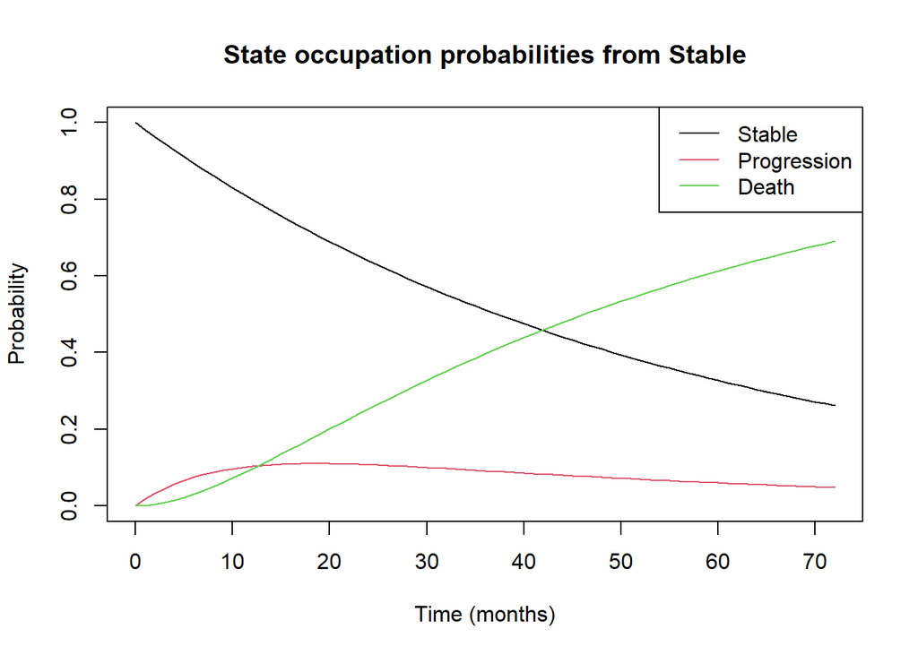

```r
# Plot : Transition probabilities from Stable over time
times <- seq(0, 72, by = 1)
probs <- sapply(times, function(t) pmatrix.msm(msm_fit, t = t)[1, ])
matplot(times, t(probs), type = "l", lty = 1, col = 1:3,
        xlab = "Time (months)", ylab = "Probability",
        main = "State occupation probabilities from Stable")
legend("topright", legend = states, col = 1:3, lty = 1)
```

```r
pt_A_12 <- pmatrix.msm(msm_fit, t = 12, covariates = list(Arm = "A"))
pt_B_12 <- pmatrix.msm(msm_fit, t = 12, covariates = list(Arm = "B"))
pt_C_12 <- pmatrix.msm(msm_fit, t = 12, covariates = list(Arm = "C"))

pt_A_12
```

```
##                Stable Progression     Death
## Stable      0.7281326   0.1472824 0.1245850
## Progression 0.0000000   0.2733824 0.7266176
## Death       0.0000000   0.0000000 1.0000000
```

```r
pt_B_12
```

```
##                Stable Progression      Death
## Stable      0.8380126  0.07402379 0.08796361
## Progression 0.0000000  0.17012648 0.82987352
## Death       0.0000000  0.00000000 1.00000000
```

```r
pt_C_12
```

```
##                Stable Progression      Death
## Stable      0.8298791  0.09244757 0.07767335
## Progression 0.0000000  0.26622266 0.73377734
## Death       0.0000000  0.00000000 1.00000000
```

**Arm A:**

- If starting Stable, 72.8% remain stable, 14.7% progress and 12.5% die.
- If starting Progression, 27.3% keeps progressing and 72.7% die.

**Arm B:**

- If starting Stable, 83.8% remain stable, 7.4% progress and 8.8% die.
- If starting Progression, 17% keeps progressing and 83% die.

**Arm C:**

- If starting Stable, 83% remain stable, 9.2% progress and 7.8% die.
- If starting Progression, 26.6% progress and 73.4% die.

```r
probs_A <- sapply(times, function(t)
  pmatrix.msm(msm_fit, t = t, covariates = list(Arm = "A"))[1, ])

probs_B <- sapply(times, function(t)
  pmatrix.msm(msm_fit, t = t, covariates = list(Arm = "B"))[1, ])

probs_C <- sapply(times, function(t)
  pmatrix.msm(msm_fit, t = t, covariates = list(Arm = "C"))[1, ])
```

## Plots

# Probability of remaining Stable by Treatment

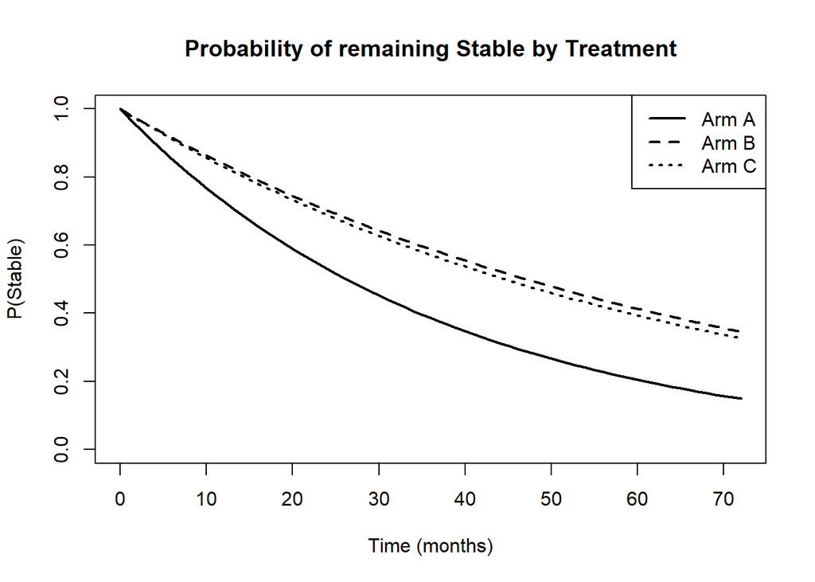

```r
plot(times, probs_A[1,], type = "l", lwd = 2,
     ylim = c(0,1),
     xlab = "Time (months)",
     ylab = "P(Stable)",
     main = "Probability of remaining Stable by Treatment")

lines(times, probs_B[1,], lwd = 2, lty = 2)
lines(times, probs_C[1,], lwd = 2, lty = 3)

legend("topright",
       legend = c("Arm A", "Arm B", "Arm C"),
       lty = c(1,2,3), lwd = 2)
```

# Cumulative probability of Death by Treatment

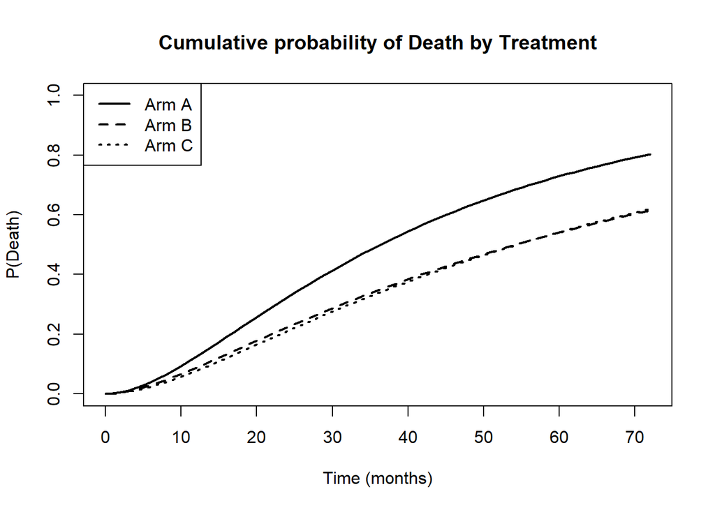

```r
plot(times, probs_A[3,], type = "l", lwd = 2,
     ylim = c(0,1),
     xlab = "Time (months)",
     ylab = "P(Death)",
     main = "Cumulative probability of Death by Treatment")

lines(times, probs_B[3,], lwd = 2, lty = 2)
lines(times, probs_C[3,], lwd = 2, lty = 3)

legend("topleft",
       legend = c("Arm A", "Arm B", "Arm C"),
       lty = c(1,2,3), lwd = 2)
```

# Probability of Death conditioned along Progression

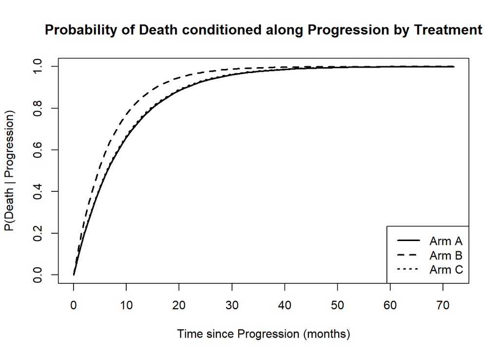

```r
#Extracting probabilites of Progression and Death for each treatment arm

times <- seq(0, 72, by = 1)
prob_death_A <- sapply(times, function(t)
  pmatrix.msm(msm_fit, t = t, covariates = list(Arm = "A"))[2, 3])

probs_death_B <- sapply(times, function(t)
  pmatrix.msm(msm_fit, t = t, covariates = list(Arm = "B"))[2, 3])

probs_death_C <- sapply(times, function(t)
  pmatrix.msm(msm_fit, t = t, covariates = list(Arm = "C"))[2, 3])


#Plot

plot(times, prob_death_A, type = "l",lwd = 2,
     ylim = c(0,1),
     xlab = "Time since Progression (months)",
     ylab = "P(Death | Progression)",
     main = "Probability of Death conditioned along Progression by Treatment")

lines(times, probs_death_B, lwd = 2, lty = 2)
lines(times, probs_death_C, lwd = 2, lty = 3)

legend("bottomright", legend = c("Arm A", "Arm B", "Arm C"), lty = c(1,2,3),lwd = 2)
```

# Long-term state occupancy

## Probailities across arms

```r
timeline <- seq(0,72, by = 2)
summary_df <- data.frame(
  Time = timeline,
  Stable_A = round(probs_A[1, match(timeline, times)],2),
  Stable_B = round(probs_B[1, match(timeline, times)],2),
  Stable_C = round(probs_C[1, match(timeline, times)],2),
  Death_A  = round(probs_A[3, match(timeline, times)],2),
  Death_B  = round(probs_B[3, match(timeline, times)],2),
  Death_C  = round(probs_C[3, match(timeline, times)],2)
)

summary_df
```

```
##    Time Stable_A Stable_B Stable_C Death_A Death_B Death_C
## 1     0     1.00     1.00     1.00    0.00    0.00    0.00
## 2     2     0.95     0.97     0.97    0.01    0.00    0.00
## 3     4     0.90     0.94     0.94    0.02    0.01    0.01
## 4     6     0.85     0.92     0.91    0.04    0.03    0.02
## 5     8     0.81     0.89     0.88    0.06    0.05    0.04
## 6    10     0.77     0.86     0.86    0.09    0.07    0.06
## 7    12     0.73     0.84     0.83    0.12    0.09    0.08
## 8    14     0.69     0.81     0.80    0.16    0.11    0.10
## 9    16     0.66     0.79     0.78    0.19    0.13    0.12
## 10   18     0.62     0.77     0.76    0.22    0.16    0.14
## 11   20     0.59     0.74     0.73    0.26    0.18    0.17
## 12   22     0.56     0.72     0.71    0.29    0.20    0.19
## 13   24     0.53     0.70     0.69    0.32    0.22    0.21
## 14   26     0.50     0.68     0.67    0.35    0.24    0.23
```

[output cut: 23 more lines]

**Summary:**